# Music Symbol Detection

## Training Results:

Model performance:

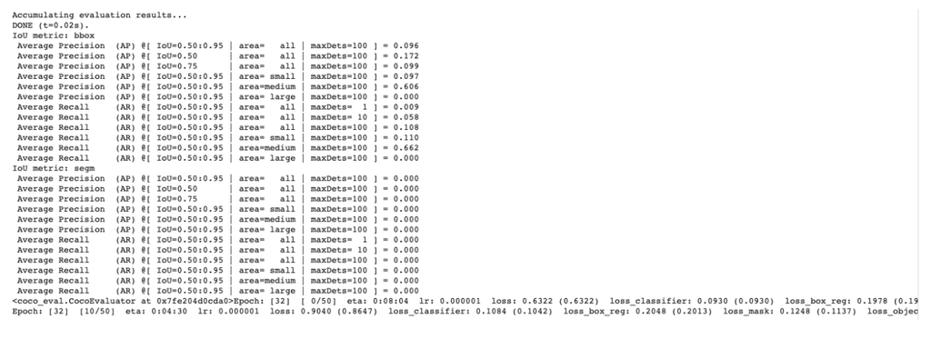

As we can see this model is able to identify mideum size bboxes 60% of this. accuracy(both AR and AP) is low for small size bboxes. in Our data set there are not large size bboxes so accuracy of largesize is shown zero

[figure not shown]

[figure not shown]

Training losses trends:

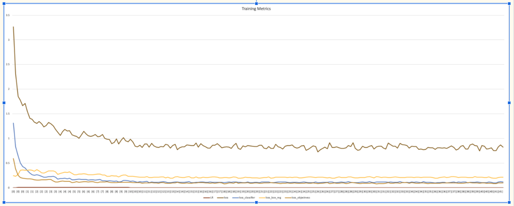

```python
#torch.save(model,MODEL_PATH)
# load save model for prediction
model = torch.load(MODEL_PATH)
model.eval()
```

```python
#@title
import matplotlib.pyplot as plt
import matplotlib.patches as patches
from PIL import Image
import numpy as np

def draw_original_prediction(img, target, pred):
    # Create figure and axes
    fig,(ax1,ax2) = plt.subplots(nrows=1,ncols=2,figsize=(50,40))
    x= img.size()[1]
    y= img.size()[2]
    if len(img.size())==3:
      im = img[0].view(x,y)
    else:
      im = img.view(x,y)

    # Display the image
    ax1.imshow(im,cmap='binary_r')
    ax1.set_title('Music Symbol Original')
    # Create a Rectangle patch
    num_objs = target['boxes'].size(0)
    for idx in range(num_objs):
      x1,y1,x2,y2 = target['boxes'][idx].tolist()
      label = target['labels'][idx].tolist()
      # calculate width and height of the box
      width, height = x2 - x1, y2 - y1
      # create the shape
      rect = patches.Rectangle((x1, y1), width, height, fill=False, linewidth=1,edgecolor=COLORS[label],facecolor='none')
      # Add the patch to the Axes
      ax1.add_patch(rect)
    # Display the image
    ax2.imshow(im,cmap='binary_r')
    ax2.set_title('Music Symbol Prediction')
    # Create a Rectangle patch
    num_objs = pred['boxes'].size(0)
    for idx in range(num_objs):
      x1,y1,x2,y2 = pred['boxes'][idx].tolist()
      label = pred['labels'][idx].tolist()
      # calculate width and height of the box
      width, height = x2 - x1, y2 - y1
      # create the shape
      rect = patches.Rectangle((x1, y1), width, height, fill=False, linewidth=1,edgecolor=COLORS[label],facecolor='none')
      # Add the patch to the Axes
      ax2.add_patch(rect)

    plt.show()
```

```python
#@title
import ipywidgets as widgets
from ipywidgets import interact, interact_manual
import os
from PIL import Image

@interact
def predict_single_file(file=os.listdir('data/training_validation_test/test')):
    print("Select Test Image")
    img = Image.open(f'data/training_validation_test/test/{file}')
    filename = file.split('.')[0]
    dataset = MuscimaDataset(dataset_type='test',transforms=get_transform(transform=False),number_channels=1,image_name=filename)
    #print(dataset[0][0].size())
    data_loader_test = torch.utils.data.DataLoader(dataset, batch_size=1, shuffle=False, num_workers=2,collate_fn=utils.collate_fn)

    device = torch.device('cuda') if torch.cuda.is_available() else torch.device('cpu')
    model.eval()
    for batch_idx, (img, target) in enumerate(data_loader_test):
      #draw_image(img[0],target[0])
      with torch.no_grad():
        prediction = model([img[0].to(device)])

      #print(f"\n\n\n{batch_idx} image predicted")
    draw_original_prediction(img[0], target[0],prediction[0])
```

[output not shown]

```python
model.eval()
for batch_idx, (img, target) in enumerate(data_loader_test):
  print(f"{batch_idx} image original")
  draw_image(img[0],target[0])
  with torch.no_grad():
    prediction = model([img[0].to(device)])

  print(f"\n\n\n{batch_idx} image predicted")
  draw_image(img[0],prediction[0])
```

[output not shown]

Watch predicting few images live on [youtube](https://youtu.be/oj4ZwiRbF1g)

# Discussion and Future Work

## Evaluation of Results

When we attempted to randomly crop our images and present them to the network, we had even lower accuracy. Hence, an improvement would be for us to manually crop the image and filter the labels that are completely contained in the cropped parts, then zoom those parts in order for them to be more visible. In conclusion, this project showed us how size affects the predictions of a model, and how we should be more careful in our our image transforms when training object detection models.

# Future Work

- Try different backbone like ResNet-101 or ResNet-152 and see if there is any improvement
- Try [Facebook Detr framework](https://github.com/facebookresearch/detr)
- Use model that are pre-trained on music dataset or create model from scratch and train it on variaty of music dataset from [here](https://apacha.github.io/OMR-Datasets/)
- In this project we did not inlink/outlink data from xml dataset. It could be useful for determining position of symbols and there relationships
- Try using distorted images from CVCMUSCIMA and see if there is any improvement in model performance.
- Researcher could also try to extend this work to build a network that can read music sheet and convert it into audio format.